# Covid91 vaccine study Final2022

## 1.2 Females

### 1.2.1 Graphical Descriptive Results

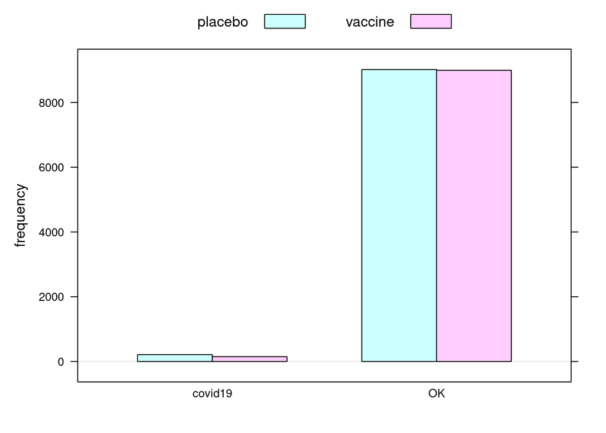

```r
barchartGC(~infected + treatment,data=Females)
```

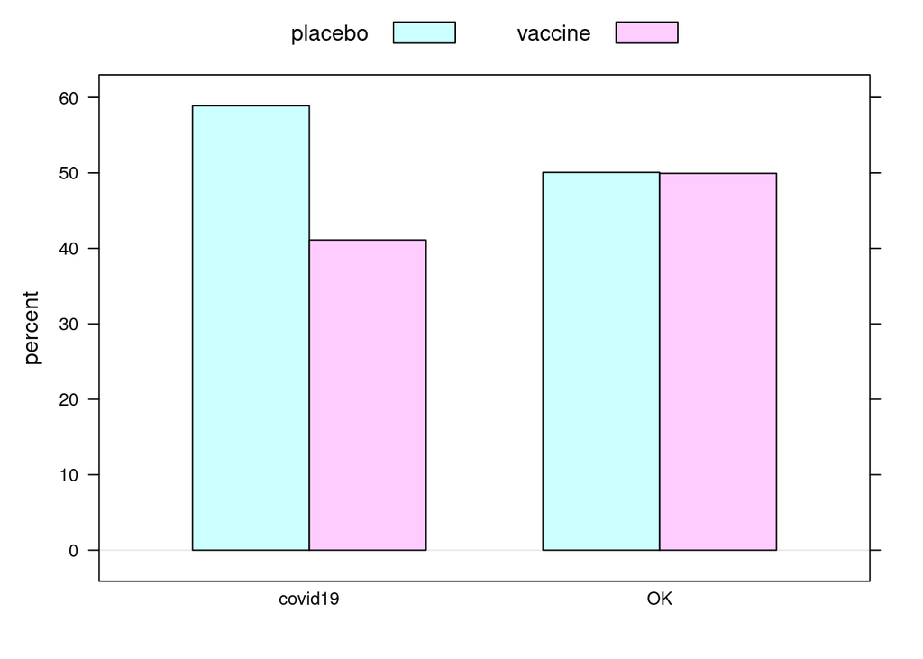

```r
barchartGC(~infected + treatment,data=Females, type="percent")
```

Based on this plot the females that took the placebo have a greater risk of contracting the virus.

### 1.2.2 Numerical Descriptive Results

```r
table1 <- xtabs(~infected + treatment,data=Females)
rowPerc(table1)
```

```
##          treatment
## infected  placebo vaccine  Total
##   covid19   58.89   41.11 100.00
##   OK        50.06   49.94 100.00
```

```r
colPerc(table1)
```

```
##          treatment
## infected  placebo vaccine
##   covid19     2.3    1.62
##   OK         97.7   98.38
##   Total     100.0  100.00
```

the table shows that the females that took the placebo are more likely to contract the virus.  
### Inferential results

```r
chisq.test(table1)
```

```
##
##  Pearson's Chi-squared test with Yates' continuity correction
##
## data:  table1
## X-squared = 10.652, df = 1, p-value = 0.0011
```

```r
chisqtestGC(table1)
```

```
## Pearson's Chi-squared test with Yates' continuity correction
##
## Observed Counts:
##          treatment
## infected  placebo vaccine
##   covid19     212     148
##   OK         9016    8994
##
## Counts Expected by Null:
##          treatment
## infected  placebo vaccine
##   covid19  180.84  179.16
##   OK      9047.16 8962.84
##
## Contributions to the chi-square statistic:
##          treatment
## infected  placebo vaccine
##   covid19    5.37    5.42
##   OK         0.11    0.11
##
##
## Chi-Square Statistic = 10.652
## Degrees of Freedom of the table = 1
## P-Value = 0.0011
```

```r
fisher.test(table1)
```

```
##
##  Fisher's Exact Test for Count Data
##
## data:  table1
## p-value = 0.0009484
## alternative hypothesis: true odds ratio is not equal to 1
## 95 percent confidence interval:
##  1.150398 1.778592
## sample estimates:
## odds ratio
##   1.428903
```

from the chi-squared test, the p-value is 0.0011 which is less than 0.05, so we reject the Null hypothesis.  
From the fisher’s exact test, the p-value is 0.00094.  
the odds ratio shows that there are 1.4 chances that the females that take the vaccine will not contract the vaccine.

### 1.2.3 Females Conclusion

to conclude, since from the analysis it is seen that the females that take the vaccine are more likely to not contract the the vaccine,so I recommend that the subgroup females should use the vaccine.